# BSMM-lab-3

BSMM 8740 Fall 2023

Author

Anshul

Published

January 10, 2024

## Setup

Load packages and data:

```r
boston_cocktails <- readr::read_csv('data/boston_cocktails.csv')
```

```r
library(magrittr)   # the pipe
library(tidyverse)  # for data wrangling + visualization
library(tidymodels) # for modeling
library(gt)
```

## Exercises

### Exercise 1

```r
view(boston_cocktails)
```

```r
boston_cocktails %>% skimr::skim()
```

Data summary

| Name | Piped data |
| --- | --- |
| Number of rows | 2542 |
| Number of columns | 7 |
| _______________________ |  |
| Column type frequency: |  |
| character | 4 |
| numeric | 3 |
| ________________________ |  |
| Group variables | None |

**Variable type: character**

| skim_variable | n_missing | complete_rate | min | max | empty | n_unique | whitespace |
| --- | --- | --- | --- | --- | --- | --- | --- |
| name | 0 | 1 | 4 | 36 | 0 | 937 | 0 |
| category | 0 | 1 | 3 | 21 | 0 | 11 | 0 |
| ingredient | 0 | 1 | 3 | 23 | 0 | 40 | 0 |
| measure | 0 | 1 | 1 | 8 | 0 | 28 | 0 |

**Variable type: numeric**

| skim_variable | n_missing | complete_rate | mean | sd | p0 | p25 | p50 | p75 | p100 | hist |
| --- | --- | --- | --- | --- | --- | --- | --- | --- | --- | --- |
| row_id | 0 | 1 | 495.37 | 284.75 | 1.00 | 261.25 | 497 | 730.75 | 990 | ▇▇▇▇▇ |
| ingredient_number | 0 | 1 | 2.54 | 1.29 | 1.00 | 1.00 | 2 | 3.00 | 6 | ▇▃▂▁▁ |
| measure_number | 0 | 1 | 0.98 | 0.72 | 0.02 | 0.50 | 1 | 1.50 | 16 | ▇▁▁▁▁ |

```r
boston_cocktails %>% DataExplorer::introduce()
```

```
# A tibble: 1 × 9
   rows columns discrete_columns continuous_columns all_missing_columns
  <int>   <int>            <int>              <int>               <int>
1  2542       7                4                  3                   0
# ℹ 4 more variables: total_missing_values <int>, complete_rows <int>,
#   total_observations <int>, memory_usage <dbl>
```

```r
boston_cocktails %>% dplyr::summarize(
  Median = median(measure_number)
)
```

```
# A tibble: 1 × 1
  Median
   <dbl>
1      1
```

The median measure amount across across all cocktails is **1**.

### Exercise 2

```r
boston_cocktails_processed <- boston_cocktails %>% dplyr::select(name,category,ingredient,measure_number) %>% tidyr::replace_na(list(measure_number = 0)) %>% pivot_wider(names_from = ingredient,values_from = measure_number) %>% replace(is.na(.), 0) %>% janitor::clean_names()

boston_cocktails_processed %>% dplyr::select( gin,name) %>%dplyr::filter(name == "Leap Frog Highball")
```

```
# A tibble: 1 × 2
    gin name
  <dbl> <chr>
1     2 Leap Frog Highball
```

The **Leap Frog Highball** contains **2** measures of gin

### Exercise 3

```r
#step normalization
aq_recipe <- recipes::recipe( ~ ., data = boston_cocktails_processed)
aq_recipe <- aq_recipe %>% recipes::update_role(name, category, new_role = 'id')
aq_step_norm <- aq_recipe %>% recipes::step_normalize(all_numeric()) %>% recipes::step_pca(all_numeric())
aq_step_prep <- recipes::prep(aq_step_norm)


#center and scaling normalization
aq_step_prep_n2 <- recipes::recipe( ~ ., data = boston_cocktails_processed) %>%  recipes::update_role(name, category, new_role = 'id') %>%
recipes::step_center(recipes::all_numeric()) %>%
recipes::step_scale(recipes::all_numeric()) %>%
recipes::step_pca(recipes::all_numeric()) %>% recipes::prep()


aq_step_prep_n2
```

```
── Recipe ──────────────────────────────────────────────────────────────────────
```

```
── Inputs
```

```
Number of variables by role
```

```
predictor: 40
id:         2
```

```
── Training information
```

```
Training data contained 937 data points and no incomplete rows.
```

```
── Operations
```

```
• Centering for: light_rum, lemon_juice, lime_juice, ... | Trained
```

```
• Scaling for: light_rum, lemon_juice, lime_juice, ... | Trained
```

```
• PCA extraction with: light_rum, lemon_juice, lime_juice, ... | Trained
```

40 predictor variables are prepped by the recipe.

### Exercise 4

```r
aq_step_prep %>% recipes::tidy(1) %>% dplyr::arrange(desc(value))
```

```
# A tibble: 80 × 4
   terms            statistic value id
   <chr>            <chr>     <dbl> <chr>
 1 orange_juice     sd        0.776 normalize_KQZKu
 2 gin              sd        0.564 normalize_KQZKu
 3 light_rum        sd        0.477 normalize_KQZKu
 4 vodka            sd        0.476 normalize_KQZKu
 5 lemon_juice      sd        0.451 normalize_KQZKu
 6 blanco_tequila   sd        0.407 normalize_KQZKu
 7 lime_juice       sd        0.389 normalize_KQZKu
 8 bourbon_whiskey  sd        0.374 normalize_KQZKu
 9 grapefruit_juice sd        0.373 normalize_KQZKu
10 brandy           sd        0.357 normalize_KQZKu
# ℹ 70 more rows
```

```r
aq_step_prep_n2 %>% recipes::tidy(1) %>% dplyr::arrange(desc(value))
```

```
# A tibble: 40 × 3
   terms           value id
   <chr>           <dbl> <chr>
 1 gin            0.252  center_xcwUi
 2 lemon_juice    0.229  center_xcwUi
 3 orange_juice   0.185  center_xcwUi
 4 vodka          0.168  center_xcwUi
 5 light_rum      0.161  center_xcwUi
 6 lime_juice     0.138  center_xcwUi
 7 blanco_tequila 0.110  center_xcwUi
 8 brandy         0.0990 center_xcwUi
 9 dry_vermouth   0.0942 center_xcwUi
10 powdered_sugar 0.0891 center_xcwUi
# ℹ 30 more rows
```

### Exercise 5

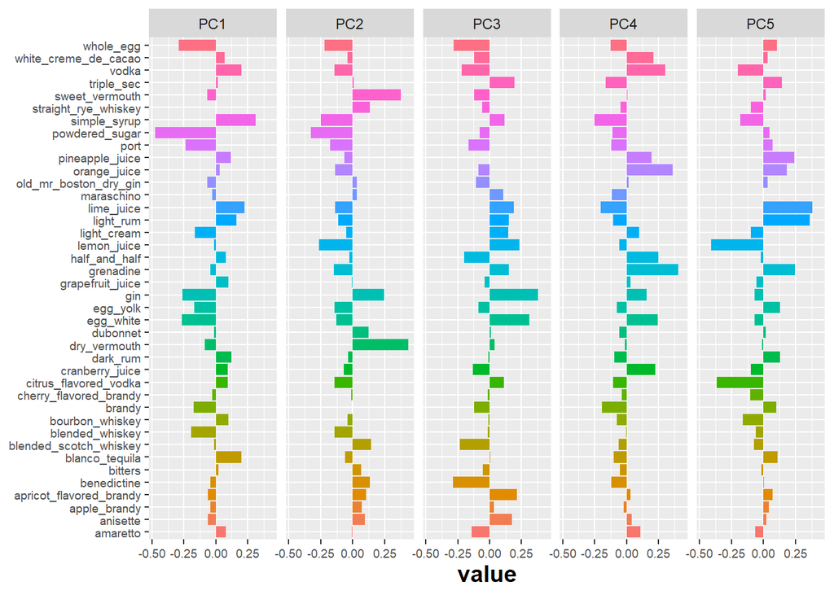

```r
drinks_data <- aq_step_prep %>% recipes::tidy(2)
drinks_data_1_to_5 <- drinks_data %>% dplyr::filter(component %in% c("PC1","PC2","PC3","PC4","PC5")) %>% dplyr::mutate(order = forcats::fct_inorder(component))

drinks_data_1_to_5 %>% ggplot(aes(value, terms, fill = terms)) +
geom_col(show.legend = FALSE) +
facet_wrap(~component, nrow = 1) +
labs(y = NULL) +
theme(axis.text=element_text(size=7),
      axis.title=element_text(size=14,face="bold"))
```

Describe describe the drinks represented by PC1?

**Sweet & syrupy**, **mildly bitter** with **moderate to high** alcohol content

### Exercise 6

```r
drinks_data %>% dplyr::filter(component %in% c("PC1","PC2","PC3","PC4")) %>% group_by(component)%>% dplyr::slice_max(abs(value),n = 8) %>% gt() %>% data_color(
  columns = c(value),
  colors = scales::col_numeric(
    palette = c("red","green"),
    domain = c(-1, 1)
  )
)
```

| terms | value | id |
| --- | --- | --- |
| PC1 |  |  |
| powdered_sugar | -0.4764442 | pca_iX9UB |
| simple_syrup | 0.3125978 | pca_iX9UB |
| whole_egg | -0.2903794 | pca_iX9UB |
| egg_white | -0.2643614 | pca_iX9UB |
| gin | -0.2588481 | pca_iX9UB |
| port | -0.2354010 | pca_iX9UB |
| lime_juice | 0.2240295 | pca_iX9UB |
| blanco_tequila | 0.2025436 | pca_iX9UB |
| PC2 |  |  |
| dry_vermouth | 0.4332412 | pca_iX9UB |
| sweet_vermouth | 0.3754366 | pca_iX9UB |
| powdered_sugar | -0.3273723 | pca_iX9UB |
| lemon_juice | -0.2651836 | pca_iX9UB |
| simple_syrup | -0.2512150 | pca_iX9UB |
| gin | 0.2437374 | pca_iX9UB |
| whole_egg | -0.2191547 | pca_iX9UB |
| port | -0.1763370 | pca_iX9UB |
| PC3 |  |  |
| gin | 0.3780348 | pca_iX9UB |
| egg_white | 0.3094631 | pca_iX9UB |
| benedictine | -0.2864463 | pca_iX9UB |
| whole_egg | -0.2825812 | pca_iX9UB |
| blended_scotch_whiskey | -0.2352922 | pca_iX9UB |
| lemon_juice | 0.2318927 | pca_iX9UB |
| vodka | -0.2167814 | pca_iX9UB |
| apricot_flavored_brandy | 0.2134899 | pca_iX9UB |
| PC4 |  |  |
| grenadine | 0.4068737 | pca_iX9UB |
| orange_juice | 0.3625622 | pca_iX9UB |
| vodka | 0.3008406 | pca_iX9UB |
| simple_syrup | -0.2533007 | pca_iX9UB |
| half_and_half | 0.2493552 | pca_iX9UB |
| egg_white | 0.2465323 | pca_iX9UB |
| cranberry_juice | 0.2228099 | pca_iX9UB |
| white_creme_de_cacao | 0.2089063 | pca_iX9UB |

The characteristic alcoholic beverage of each of the first 4 principle components is gin & vodka.

### Exercise 7

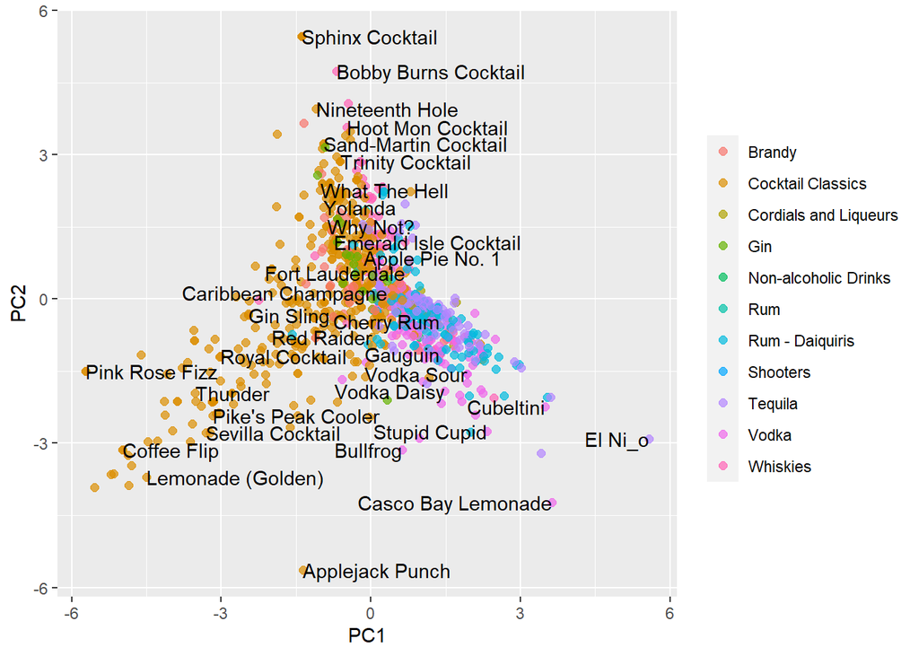

```r
recipes::bake(aq_step_prep,boston_cocktails_processed) %>% ggplot(aes(PC1, PC2, label = name)) +
  geom_point(aes(color = category), alpha = 0.7, size = 2) +
  geom_text(check_overlap = TRUE, hjust = "inward") +
  labs(color = NULL)
```

How would you interpret the results of a PCA analysis for a client?

PC1 and PC2 have negative values for light cocktail classics, which means PC1 and PC2 do not focus on cocktail classics, drinks under these categories will less likely be cordials/liqeurs and light cocktail classics. PC1 focuses on unmixed heavy alcohol and less cocktails. PC2 comprises of cocktail oriented drinks and less straightup alcohol. It will still contain moderate level of alcohol.